# Final Project: BeautifulSoup Documentation Analytics System

**Team Project - Course: PDS301m (Python for Data Science)**

**Project Goal:** Build an end-to-end data pipeline to collect, parse, extract, and analyze structural metadata from the official BeautifulSoup documentation page (Feature 6 Focus).

**Target URL:** https://www.crummy.com/software/BeautifulSoup/bs4/doc/

## Project Architecture

The core logic lives in the `src/` Python package, allowing both scripts and interactive notebooks to run the same code:

| File | Component | Description |
| --- | --- | --- |
| `src/collector.py` | Feature 1: Web Page Collector | Downloads and saves raw HTML |
| `src/parser.py` | Feature 2: HTML Parser | Parses HTML with BeautifulSoup |
| `src/extractor.py` | Features 3, 4, 5: Data Extractors | Extracts Sections, Links, and Code Examples to CSVs |
| `src/analyzer.py` | Feature 6: Doc Analytics | Answers 8 required and 2 additional analytics questions |
| `src/visualizer.py` | Feature 7: Data Visualization | Generates 4 charts saved to `output/charts/` |
| `src/report_generator.py` | Feature 8: Final Report | Generates Markdown & HTML report in `output/` |
| `src/main.py` | Orchestration Pipeline | Runs the entire pipeline sequentially (Features 1-8) |

The cells below walk through the entire pipeline step-by-step.

## 1. Import Required Libraries

```python
import os
import sys
import re
import requests
import pandas as pd
import numpy as np
from bs4 import BeautifulSoup

pd.set_option("display.max_columns", None)
pd.set_option("display.max_colwidth", 100)
```

## 2. Set Project Working Directory & Paths

```python
# Set current directory to project root
if "src" in os.listdir(".") or "notebooks" in os.listdir("."):
    print("Currently in root.")
else:
    PROJECT_ROOT = os.path.abspath(os.path.join(os.getcwd(), os.pardir))
    os.chdir(PROJECT_ROOT)
    print("Changed working directory to project root:", os.getcwd())

sys.path.insert(0, os.getcwd())

# Create directories
os.makedirs("data/raw", exist_ok=True)
os.makedirs("data/processed", exist_ok=True)
print("Folders checked & initialized.")
```

```
Changed working directory to project root: D:\PRJ\FinalProjectPDS301m
Folders checked & initialized.
```

## 3. Feature 1 – Web Page Collector

Downloads the official BeautifulSoup documentation using `requests` and saves it to `data/raw/beautifulsoup_doc.html`.

```python
from src import collector

html = collector.collect()
print("Feature 1 completed successfully.")
```

```
Downloading: https://www.crummy.com/software/BeautifulSoup/bs4/doc/
```

```
Raw HTML saved to: data\raw\beautifulsoup_doc.html  (380,701 characters)
Feature 1 completed successfully.
```

## 4. Feature 2 – HTML Parser

Parses the local HTML file into a BeautifulSoup tree structure.

```python
from src import parser

soup = parser.parse()
print("Feature 2 completed successfully.")
```

```
Loading HTML from: data\raw\beautifulsoup_doc.html
```

```
Page title: Beautiful Soup Documentation — Beautiful Soup 4.14.3 documentation
Feature 2 completed successfully.
```

## 5. Feature 3 – Section Extractor

Extracts sections (h1, h2, h3 headings), computes section word count, code blocks count, and links count, saving results to `data/processed/sections.csv`.

```python
from src import extractor

sections_df = extractor.extract_sections(soup)
extractor.save_sections(sections_df)
print(f"Feature 3 completed: Extracted {len(sections_df)} sections.")
sections_df.head(5)
```

```
Feature 3 completed: Extracted 113 sections.
```

|  | section_id | section_level | section_title | section_text | word_count | code_block_count | link_count |
| --- | --- | --- | --- | --- | --- | --- | --- |
| 0 | 1 | h1 | Beautiful Soup Documentation ¶ | Beautiful Soup is a Python library for pulling data out of HTML and XML files. It works with you... | 310 | 0 | 14 |
| 1 | 2 | h2 | Getting help ¶ | If you have questions about Beautiful Soup, or run into problems, send mail to the discussion gr... | 97 | 0 | 4 |
| 2 | 3 | h3 | API documentation ¶ | This document is written like an instruction manual, but you can also read traditional API docum... | 43 | 0 | 1 |
| 3 | 4 | h1 | Quick Start ¶ | Here's an HTML document I'll be using as an example throughout this document. It's part of a sto... | 422 | 6 | 0 |
| 4 | 5 | h1 | Installing Beautiful Soup ¶ | If you're using a recent version of Debian or Ubuntu Linux, you can install Beautiful Soup with ... | 431 | 18 | 6 |

## 6. Feature 4 – Link Extractor

Extracts all hyperlinks, classifies them based on location and destination rules, and saves them to `data/processed/links.csv`.

```python
links_df = extractor.extract_links(soup)
extractor.save_links(links_df)
print(f"Feature 4 completed: Extracted {len(links_df)} links.")
links_df.head(5)
```

```
Feature 4 completed: Extracted 504 links.
```

|  | link_text | href | link_type | section_title |
| --- | --- | --- | --- | --- |
| 0 | ¶ | #beautiful-soup-documentation | internal_anchor | Beautiful Soup Documentation ¶ |
| 1 | Beautiful Soup | http://www.crummy.com/software/BeautifulSoup/ | documentation_link | Beautiful Soup Documentation ¶ |
| 2 | Beautiful Soup 3 | http://www.crummy.com/software/BeautifulSoup/bs3/documentation.html | documentation_link | Beautiful Soup Documentation ¶ |
| 3 | Porting code to BS4 | #porting-code-to-bs4 | internal_anchor | Beautiful Soup Documentation ¶ |
| 4 | 这篇文档当然还有中文版. | https://www.crummy.com/software/BeautifulSoup/bs4/doc.zh/ | documentation_link | Beautiful Soup Documentation ¶ |

## 7. Feature 5 – Code Example Extractor

Extracts all Python code examples, counts their lines of code, identifies specific BS4 API calls, and saves them to `data/processed/code_examples.csv`.

```python
code_df = extractor.extract_code_examples(soup)
extractor.save_code_examples(code_df)
print(f"Feature 5 completed: Extracted {len(code_df)} code blocks.")
code_df.head(5)
```

```
Feature 5 completed: Extracted 220 code blocks.
```

|  | example_id | section_title | code_text | line_count | contains_find_all | contains_find | contains_select | contains_get_text | contains_requests |
| --- | --- | --- | --- | --- | --- | --- | --- | --- | --- |
| 0 | ex_1 | Quick Start ¶ | html_doc = """<html><head><title>The Dormouse's story</title></head>\n<body>\n<p class="title"><... | 12 | False | False | False | False | False |
| 1 | ex_2 | Quick Start ¶ | from bs4 import BeautifulSoup\nsoup = BeautifulSoup(html_doc, 'html.parser')\n\nprint(soup.prett... | 36 | False | False | False | False | False |
| 2 | ex_3 | Quick Start ¶ | soup.title\n# <title>The Dormouse's story</title>\n\nsoup.title.name\n# u'title'\n\nsoup.title.s... | 28 | True | True | False | False | False |
| 3 | ex_4 | Quick Start ¶ | for link in soup.find_all('a'):\n print(link.get('href'))\n# http://example.com/elsie\n# http... | 5 | True | False | False | False | False |
| 4 | ex_5 | Quick Start ¶ | print(soup.get_text())\n# The Dormouse's story\n#\n# The Dormouse's story\n#\n# Once upon a time... | 12 | False | False | False | True | False |

## 8. Feature 6 – Documentation Analytics

Using Pandas and NumPy, answers all 8 required analytics questions and 2 additional questions.

```python
from src import analyzer

analytics_results = analyzer.analyze()
```

```
============================================================
           FEATURE 6: DOCUMENTATION ANALYTICS
============================================================
Q1: How many sections are in the documentation?
    -> 113 sections

Q2: Which section has the highest word count?
    -> "Searching the tree ¶" (4711 words)

Q3: Which section contains the most code examples?
    -> "Searching the tree ¶" (208 code blocks)

Q4: Which section contains the most links?
    -> "Table of Contents" (127 links)

Q5: What are the top 10 most frequent technical keywords?
    1. soup: 926 times
    2. tag: 746 times
    3. class: 511 times
    4. html: 420 times
    5. example: 419 times
    6. string: 387 times
    7. com: 383 times
    8. href: 378 times
    9. http: 363 times
    10. beautiful: 351 times

Q6: How many internal and external links exist?
    -> Page-internal anchor links: 470
    -> Documentation links (domain-internal): 15
    -> External domain links: 17
    -> Image links: 0
    -> Empty or invalid links: 2
    * Note: If documentation links are grouped as internal, total internal is 485.

Q7: How many code examples use find_all()?
    -> 41 examples

Q8: How many code examples use get_text()?
    -> 4 examples

------------------------------------------------------------
           ADDITIONAL ANALYTICAL QUESTIONS
------------------------------------------------------------
Q9 (Additional): Average lines of code examples & section with the longest example?
    -> Average lines per code example: 6.34 lines
    -> Longest code example is in section "Parsing only part of a document ¶" (37 lines)

Q10 (Additional): Statistics by heading level (h1, h2, h3):
                word_count        code_block_count      link_count
                      mean    sum             mean  sum       mean  sum
section_level
h1             1011.210526  19213        40.947368  778  18.631579  354
h2              295.711538  15377        12.038462  626   4.846154  252
h3              153.833333   6461         8.261905  347   4.714286  198
============================================================
```

## 9. Feature 7 – Data Visualization

Generates 4 required charts using Matplotlib and saves them to `output/charts/`:

- Bar chart: Top 10 sections by word count
- Bar chart: Number of code examples by section
- Pie chart: Link type distribution
- Histogram: Code example line count distribution

```
============================================================
           FEATURE 7: DATA VISUALIZATION
============================================================
```

```
  [1/4] Bar chart - Top 10 sections by word count  -> output\charts\chart_top_sections_word_count.png
```

```
  [2/4] Bar chart - Code examples by section       -> output\charts\chart_code_examples_by_section.png
```

```
  [3/4] Pie chart  - Link type distribution        -> output\charts\chart_link_type_distribution.png
```

```
  [4/4] Histogram  - Code line count distribution  -> output\charts\chart_code_line_count_histogram.png

  All 4 charts saved to: output\charts
============================================================

--- chart_top_sections_word_count.png ---
```

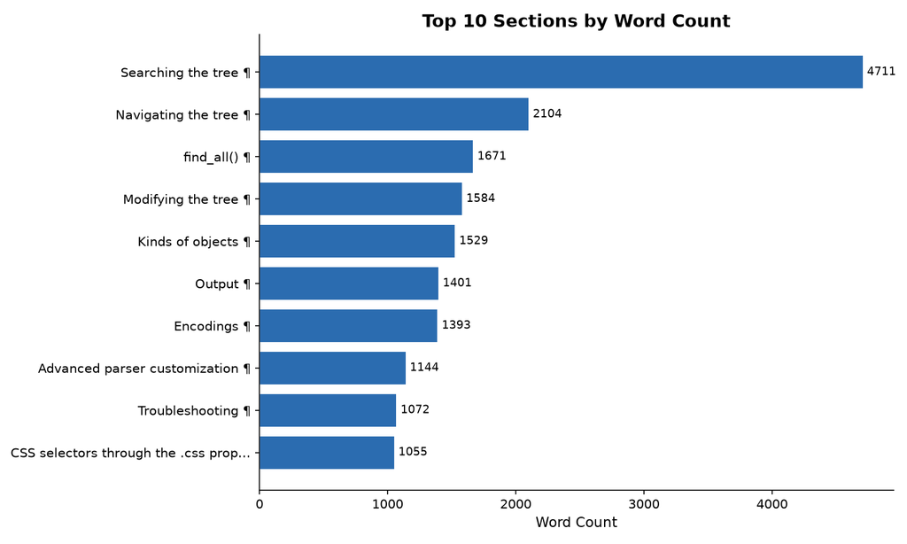

```
--- chart_code_examples_by_section.png ---
```

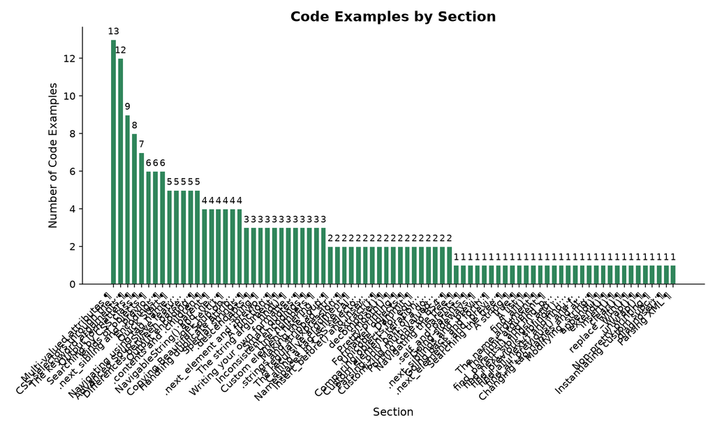

```
--- chart_link_type_distribution.png ---
```

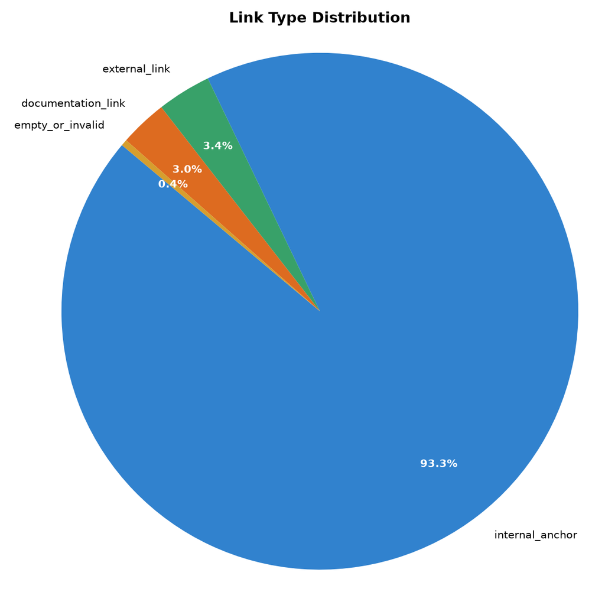

```
--- chart_code_line_count_histogram.png ---
```

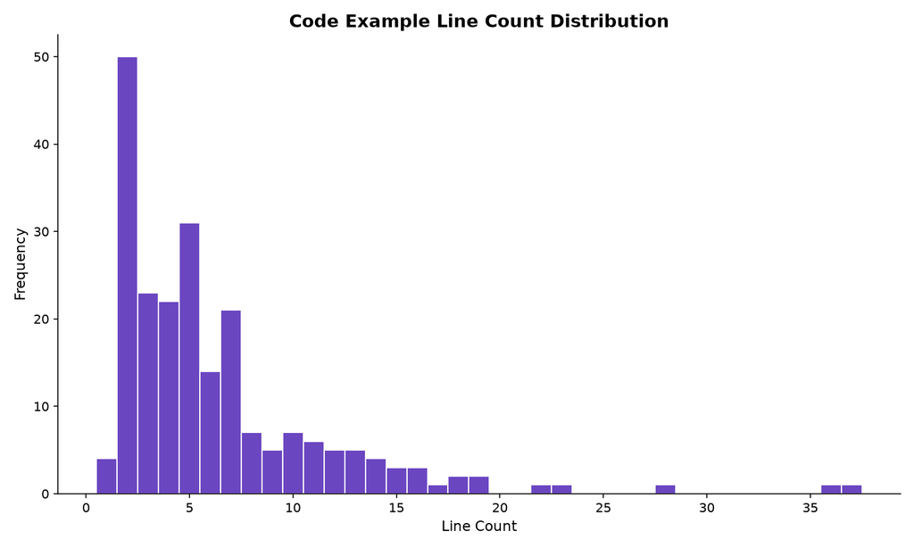

```python
from src import visualizer

chart_paths = visualizer.visualize()

# Display charts inline
import matplotlib.pyplot as plt
from IPython.display import Image, display

for chart_path in chart_paths:
    print(f"\n--- {chart_path.name} ---")
    display(Image(filename=str(chart_path)))
```

## 10. Feature 8 – Final Report Generator

Generates a comprehensive final analytical report in Markdown and styled HTML, including dataset overview, scraping method, extracted data summary, analysis results, embedded charts, key findings, limitations, and conclusion.

```python
from src import report_generator

md_path, html_path = report_generator.generate_report(
    results=analytics_results, chart_paths=chart_paths
)
print(f"\nReport generated:\n  Markdown: {md_path}\n  HTML:     {html_path}")
```

```
============================================================
           FEATURE 8: FINAL REPORT GENERATOR
============================================================
```

```
  Markdown report saved: output\final_report.md
  HTML report saved:     output\final_report.html
============================================================

Report generated:
  Markdown: output\final_report.md
  HTML:     output\final_report.html
```

## Submission Checklist

Verify that the following project components are present before finalizing:

- `src/collector.py` (Feature 1)
- `src/parser.py` (Feature 2)
- `src/extractor.py` (Feature 3, 4, 5)
- `src/analyzer.py` (Feature 6)
- `src/visualizer.py` (Feature 7)
- `src/report_generator.py` (Feature 8)
- `src/main.py` (Orchestrator — Features 1-8)
- `data/raw/beautifulsoup_doc.html` (Raw HTML)
- `data/processed/sections.csv`, `links.csv`, `code_examples.csv` (Extracted CSVs)
- `output/charts/` (4 visualization charts)
- `output/final_report.md` (Markdown report)
- `output/final_report.html` (Styled HTML report)
- `notebooks/FinalProject_BeautifulSoup_Analysis.ipynb` (This notebook)